# Analyse des données sur les infrastructures aéroportuaires

Ismaël Madou Gagi Grema

Nikita Pomozov

2024-12-18

Abstract

La problématique est d’appréhender l’impact du revenu national sur les infrastructures aéroportuaires ainsi que les choix des différents pays dans le développement des infrastructures aéroportuaires.

# **Les acronyms des pays utilisés pour l’analyse**

### Pays

| Acronyme | Pays |
| --- | --- |
| AE | Emirats Arabes Unis |
| BR | Brésil |
| CA | Canada |
| CN | Chine |
| JP | Japon |
| KR | Corée du Sud |
| US | États-Unis |

### Types d’aéroports

| Acronyme | Type d’aéroport |
| --- | --- |
| Small_airports | Petit aéroport |
| medium_airport | Moyen aéroport |
| large_airport | Grand aéroport |
| heliport | Héliport |
| closed | Fermé |
| balloonport | Port de ballons |
| seaplane_base | Base d’hydravions |

# **Introduction**

Les aéroports jouent un rôle central dans le transport aérien mondial, facilitant les échanges internationaux, le tourisme, les affaires et le commerce. En tant qu’infrastructures stratégiques, leur gestion et leur développement sont essentiels pour les économies locales et mondiales.

Cette étude se concentre sur une base de données regroupant des informations détaillées sur les aéroports du monde, incluant leur localisation, leur type et leurs caractéristiques, répartis à travers différents pays.

À travers cette analyse, nous explorerons des variables clés telles que le type d’aéroport (grands, petits, moyens, héliports, etc.) et les codes ISO des pays en utilisant la méthode d’AFC, afin de comprendre les choix des pays dans le développement des infrastructures aéroportuaires. D’autre part, nous étudierons des variables telles que le revenu national (provenant d’une autre base de données fusionnée avec la présente base), le nombre de passagers, la longueur des pistes ainsi que leur largeur, en utilisant la méthode de l’ACP pour évaluer l’impact des revenus nationaux sur le développement de ces infrastructures.

La problématique est de comprendre les choix des pays dans la construction des infrastructures aéroportuaires, mais également d’analyser l’impact des revenus nationaux sur la mise en œuvre de ces infrastructures. Cela nous permettra de déterminer si les pays les plus riches investissent davantage dans les aéroports et si cela se traduit par une augmentation du nombre de passagers.

# **Section 1: les choix des pays dans le developpement des infrastructures**

À ce niveau, nous avons regroupé les pays ayant un nombre d’aéroports inférieur à 200 dans une classe appelée “autres”. Cela nous donne, dans ce cas, 38 pays au lieu de 245. Cette modification a été réalisée suite à une remarque de M. Regnault, qui a souligné que l’AFC tend à biaiser les résultats en attribuant un poids disproportionné aux pays ayant un faible nombre d’aéroports.

Le choix des pays dans le développement des infrastructures aéroportuaires dépend de plusieurs facteurs, qui peuvent être liés à l’économie, à la politique, à la géopolitique, mais aussi à des raisons purement sociales. Les pays développés ou à revenu élevé investissent généralement massivement dans leurs infrastructures aéroportuaires en raison de leur forte demande de transport aérien et de leur rôle central dans le commerce mondial.

Les États-Unis, avec une économie développée et une politique de décentralisation, disposent de nombreux aéroports régionaux pour desservir des villes moyennes et petites. En Chine, l’urbanisation rapide et la croissance économique ont conduit à la construction d’aéroports dans des régions moins accessibles. Ces deux pays investissent massivement dans les infrastructures pour connecter efficacement leurs vastes territoires.

Le tourisme international et les échanges commerciaux renforcent également la nécessité de ces aéroports. Grâce à leur réseau aérien dense, les États-Unis et la Chine facilitent les déplacements internes et internationaux. Enfin, le développement rapide de la Chine au cours des dernières décennies a particulièrement accentué cette dynamique.

Le nombre élevé d’héliports en Corée du Sud et au Japon s’explique par plusieurs facteurs. Ces pays, fortement urbanisés, présentent une densité de population élevée dans leurs grandes villes, telles que Tokyo et Séoul, où l’espace est limité. Les hélicoptères offrent une solution de transport rapide et flexible, particulièrement utile dans les zones difficiles d’accès.

La géographie particulière de ces pays, notamment les montagnes et les nombreuses îles du Japon, rend l’utilisation des infrastructures terrestres coûteuse et complexe. Les héliports permettent de faciliter l’accès aux zones rurales ou isolées. Par ailleurs, ces nations sont fréquemment confrontées à des catastrophes naturelles, ce qui rend les hélicoptères indispensables pour les opérations de secours d’urgence.

Le Japon et la Corée du Sud ont également investi dans des technologies de pointe pour améliorer la sécurité et l’efficacité de ces infrastructures. Les héliports sont utilisés à des fins variées, notamment commerciales, médicales et militaires. Enfin, la forte demande de services aériens dans des environnements urbains densément peuplés renforce leur développement et leur utilisation.

En raison de la faible densité de population dans certaines zones et des coûts élevés pour maintenir des infrastructures aériennes, de nombreux petits aéroports ont été fermés. Les hydravions, en revanche, offrent une solution pratique et économique pour relier ces régions reculées. Au Canada, ils sont particulièrement adaptés aux conditions géographiques, comme les lacs et rivières, tandis qu’au Brésil, ils jouent un rôle crucial dans l’Amazonie, où le réseau routier est limité.

Dans des pays vastes et géographiquement variés, cette diversité est essentielle pour connecter efficacement les zones urbaines, rurales et isolées. Elle permet également de répondre à des besoins spécifiques, tels que le transport d’urgence ou l’accès à des régions éloignées. Cette combinaison assure une couverture complète et flexible du réseau aérien, adaptée à des contextes variés et à des enjeux économiques, sociaux et géographiques.

# **Section 2: L’impact des revenus nationaux sur les infrastructures aeroportuaires**

Pour analyser l’impact des revenus nationaux sur les infrastructures aéroportuaires, nous avons combiné plusieurs ensembles de données. Cela inclut des informations sur les aéroports (localisation, taille et caractéristiques), les codes ISO des pays (utilisés comme clés pour fusionner les ensembles), les revenus nationaux par habitant (comme indicateur de la richesse économique) et le trafic annuel de passagers des 50 principaux aéroports (extraits de Wikipedia en raison de limitations d’accès aux données complètes sur tous les aéroports).

En utilisant des variables comme les revenus nationaux, la longueur et la largeur des pistes, ainsi que le nombre de passagers, nous avons cherché à comprendre les relations entre ces facteurs pour déterminer si les pays les plus riches investissent davantage dans leurs aéroports et si ces investissements se traduisent par un trafic aérien accru.

L’analyse visuelle montre des différences notables entre les 50 principaux aéroports mondiaux et les 75 000 aéroports dans leur ensemble. Les grandes infrastructures, comme des pistes plus longues et plus larges, sont principalement concentrées dans ces grands aéroports. Cela s’explique par plusieurs observations : - Les pistes plus longues sont nécessaires pour accueillir des avions transcontinentaux, qui nécessitent des distances supplémentaires pour décoller et atterrir. - Ces grands aéroports agissent comme des hubs internationaux, nécessitant des investissements massifs dans les infrastructures pour répondre aux flux croissants de passagers et de marchandises.

Notre analyse a été limitée par l’accès restreint aux données détaillées sur l’ensemble des aéroports mondiaux. En conséquence, les conclusions actuelles s’appuient principalement sur les 50 top aéroports. Pour une compréhension plus complète des tendances, il serait essentiel de disposer de données couvrant une plus large gamme d’aéroports, y compris ceux situés dans des pays en développement ou dans des régions peu accessibles.

# **Conclusion**

Des éléments tels que la localisation géographique, les politiques publiques, la connectivité aérienne ou encore la dépendance au tourisme jouent un rôle déterminant dans ces variations. Ces facteurs soulignent la nécessité d’examiner de manière approfondie les anomalies et les écarts par rapport au schéma général, afin de mieux comprendre la dynamique complexe entre le développement économique, les infrastructures aéroportuaires et les flux de passagers.

Pour aller plus loin, une analyse détaillée des outliers et des facteurs externes s’avère indispensable. De plus, l’utilisation d’un ensemble de données plus exhaustif, incluant un plus grand nombre d’aéroports, serait cruciale pour confirmer ces observations et affiner les conclusions.

En résumé, le développement des infrastructures aéroportuaires reflète souvent des choix stratégiques basés sur des besoins spécifiques propres à chaque pays. Ces décisions résultent d’une combinaison de facteurs économiques, politiques et sociaux, permettant aux nations d’adapter leurs investissements pour répondre aux exigences de leurs territoires et de leurs populations.

# **Annexe**

## L’AFC

L’AFC (Analyse Factorielle des Correspondances) est une méthode statistique exploratoire utilisée pour analyser des tableaux de contingence, généralement dans le cadre de variables qualitatives. Elle permet de visualiser et d’interpréter les relations entre les lignes et les colonnes d’un tableau de contingence. Dans notre cas, nous allons analyser le tableau de contingence avec les différents pays représentés en ligne et les types d’aéroports en colonne.

La première partie de notre méthode d’AFC concerne l’analyse descriptive. Cette analyse descriptive nous permettra de résumer de façon simple et concise l’ensemble des données.

L’analyse univariée se concentre sur l’étude d’une seule variable à la fois, qu’elle soit quantitative ou qualitative. L’objectif de cette analyse est de décrire les caractéristiques de la variable et de comprendre sa distribution. Elle permet d’obtenir une première idée de la structure des données avant de passer à une analyse bivariée ou multivariée.

```
##
##    balloonport         closed       heliport  large_airport medium_airport
##             45          10164          19080            464           4747
##  seaplane_base  small_airport
##           1133          39419
```

La première variable comporte sept types d’aéroports. Le nombre d’occurrences de chaque type d’aéroport varie d’un pays à l’autre en fonction des choix stratégiques de ces derniers. Les pays ayant des orientations commerciales ont tendance à développer des aéroports petits, moyens et grands, contrairement aux pays ayant d’autres priorités.

Ensuite, nous allons présenter les graphiques des variables que nous avons retenues pour effectuer l’AFC, à savoir le type d’aéroport et le pays.

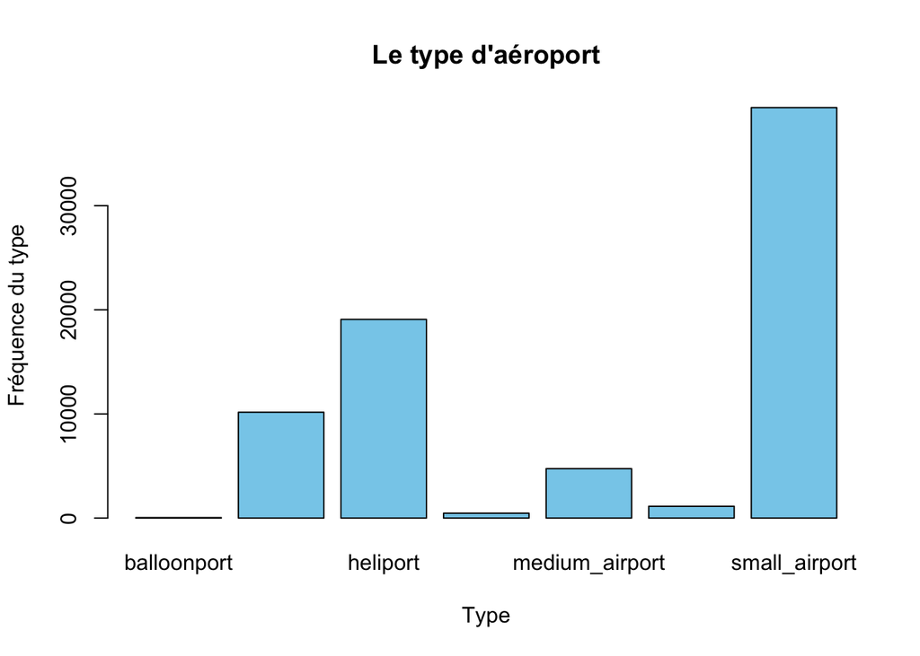

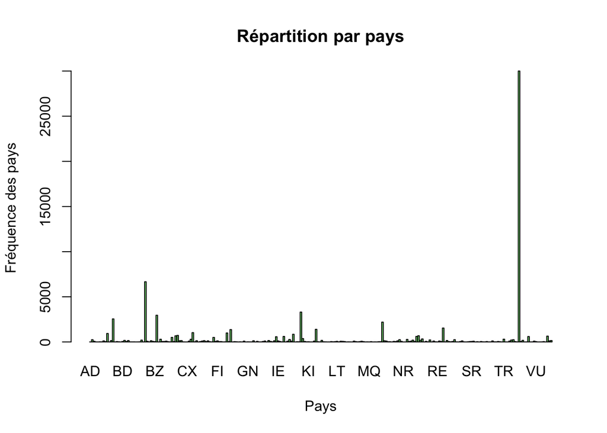

À ce niveau, on constate que les aéroports américains apparaissent très fréquemment, avec plus de 25 000 aéroports. Cela signifie que les États-Unis possèdent un nombre d’aéroports bien plus élevé que les autres pays, dont le nombre se situe généralement entre 0 et 5 000.

L’analyse bivariée est une méthode statistique utilisée pour examiner la relation entre deux variables. Dans ce cas, nous allons étudier la relation entre les variables “type” et “iso_country”.

```
##
##     AE     AR     AU Autres     BO     BR     CA     CD     CL     CN     CO
##      1      1      1    207      1      1      1      1      1      1      1
##     CZ     DE     ES     FR     GB     ID     IN     IR     IT     JP     KE
##      1      1      1      1      1      1      1      1      1      1      1
##     KR     MX     NO     NZ     PG     PH     PL     PT     RU     SE     TR
##      1      1      1      1      1      1      1      1      1      1      1
##     TZ     UA     US     VE     ZA
##      1      1      1      1      1
```

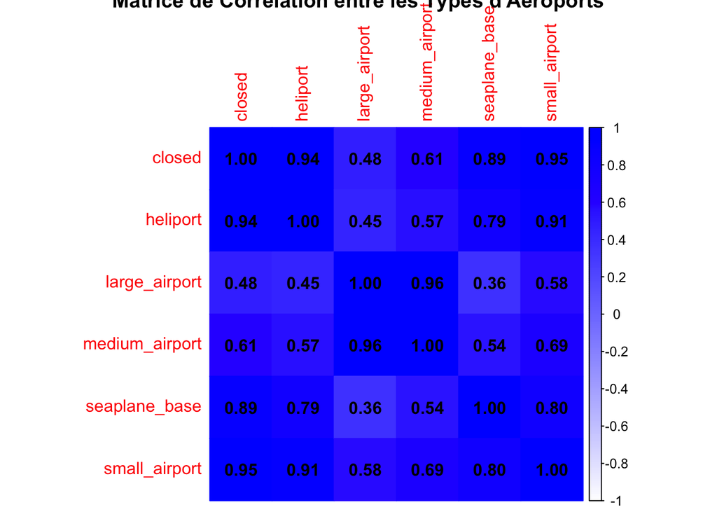

Pearson’s Chi-squared test

data: tableau_croise X-squared = 30863, df = 1458, p-value < 2.2e-16

Étant donné que la p-value est inférieure à 0,05, nous rejetons l’hypothèse nulle. Cela signifie qu’il existe une relation significative entre les deux variables qualitatives que nous avons testées. En d’autres termes, les résultats suggèrent que le type d’aéroport et le pays (ou le code ISO du pays) sont liés d’une manière statistiquement significative, et cette relation mérite d’être explorée davantage.

Fisher’s Exact Test for Count Data with simulated p-value (based on 10000 replicates)

data: tableau_croise p-value = 9.999e-05 alternative hypothesis: two.sided

Cela signifie que le test de Fisher examine une association bilatérale, c’est-à-dire qu’il teste si les deux variables sont significativement liées, sans spécifier à priori une direction particulière pour l’association.

```
##                    X^2   df P(> X^2)
## Likelihood Ratio 26501 1458        0
## Pearson          30863 1458        0
##
## Phi-Coefficient   : NA
## Contingency Coeff.: 0.54
## Cramer's V        : 0.262
```

Nous constatons une p-value faible, ce qui signifie qu’il existe une forte corrélation entre les deux variables qualitatives. De plus, les variables “coefficient de contingence” et “V de Cramér” indiquent une association modérée.

```
## X-squared
##  23537.67
```

```
## X-squared
##  1.314704
```

Avec une statistique χ² de 30863,32 et une p-value proche de 0, vous pouvez conclure qu’il existe une forte association entre les deux variables catégorielles étudiées. Cette association nous permet d’expliquer l’une des variables en fonction de l’autre, ce qui améliore la compréhension.

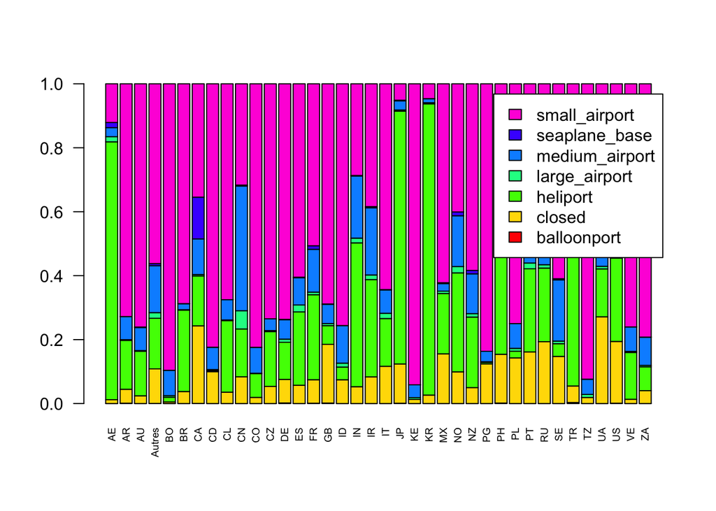

À ce niveau, nous avons un graphique qui indique la répartition des types d’aéroports pour chaque pays.

Concernant les hydravions, leur nombre est relativement faible. Cependant, nous constatons que le Canada semble développer ce type d’aéroports plus que n’importe quel autre pays.

En ce qui concerne les moyens aéroports, la Chine se distingue par le plus grand nombre de ce type d’aéroports parmi tous les pays.

De plus, le Japon, la Turquie, la Corée du Sud et les Émirats Arabes Unis ont tendance à développer davantage les héliports.

Les grands aéroports sont concentrés dans des pays comme la Chine, la Norvège et la Turquie.

Enfin, nous constatons que des pays comme l’Ukraine, la Grande-Bretagne, le Canada et les États-Unis ont fermé de nombreux aéroports, notamment en raison de plusieurs facteurs.

Cependant, nous ne pouvons rien dire concernant les ports de ballons.

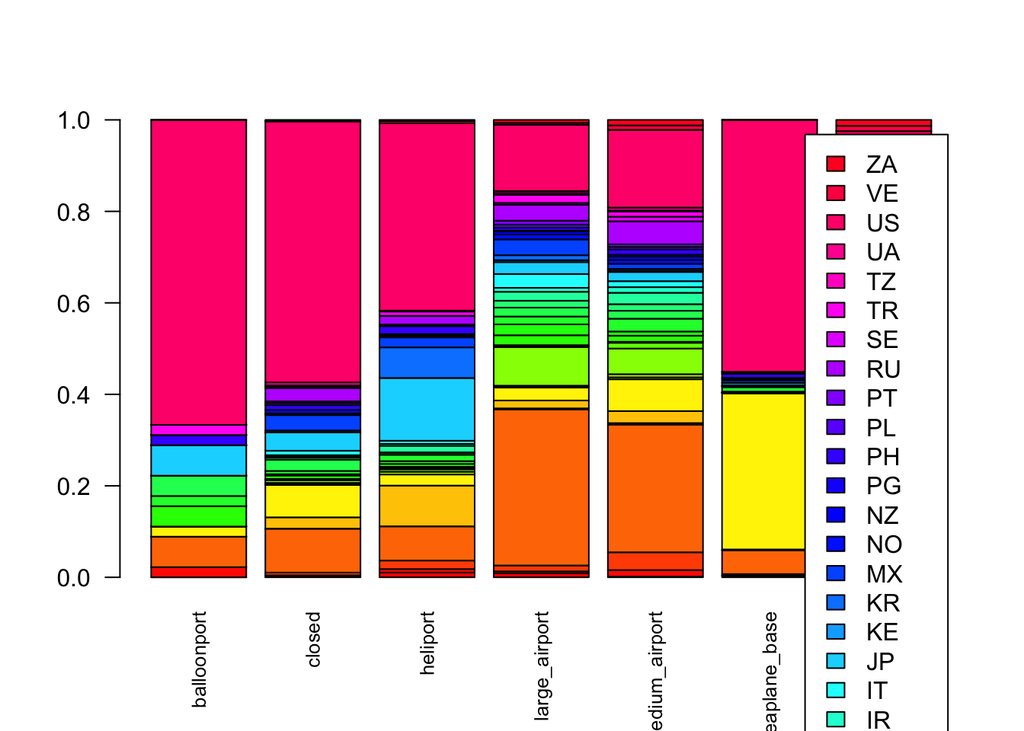

Ce barplot des profils colonnes indique la répartition de chaque type d’aéroport en fonction du pays.

On remarque que les États Unis possedent un nombre élevé de tous les types d’aéroports mis à part au niveau de “large_airport” et “medium_airport” où la Chine (le pays marqué en orange) domine.

Par ailleurs, nous notons également que le Canada (en jeune) possede plusieurs hydravions (“seaplane_base”).

```
## **Results of the Correspondence Analysis (CA)**
## The row variable has  38  categories; the column variable has 7 categories
## The chi square of independence between the two variables is equal to 23537.67 (p-value =  0 ).
## *The results are available in the following objects:
##
##    name              description
## 1  "$eig"            "eigenvalues"
## 2  "$col"            "results for the columns"
## 3  "$col$coord"      "coord. for the columns"
## 4  "$col$cos2"       "cos2 for the columns"
## 5  "$col$contrib"    "contributions of the columns"
## 6  "$row"            "results for the rows"
## 7  "$row$coord"      "coord. for the rows"
## 8  "$row$cos2"       "cos2 for the rows"
## 9  "$row$contrib"    "contributions of the rows"
## 10 "$call"           "summary called parameters"
## 11 "$call$marge.col" "weights of the columns"
## 12 "$call$marge.row" "weights of the rows"
```

```
##         eigenvalue percentage of variance cumulative percentage of variance
## dim 1 0.1655988661            52.62047396                          52.62047
## dim 2 0.0679060590            21.57773838                          74.19821
## dim 3 0.0632976134            20.11336487                          94.31158
## dim 4 0.0161109031             5.11937900                          99.43096
## dim 5 0.0015162855             0.48181284                          99.91277
## dim 6 0.0002745195             0.08723095                         100.00000
```

```
##         eigenvalue percentage of variance cumulative percentage of variance
## dim 1 0.1655988661            52.62047396                          52.62047
## dim 2 0.0679060590            21.57773838                          74.19821
## dim 3 0.0632976134            20.11336487                          94.31158
## dim 4 0.0161109031             5.11937900                          99.43096
## dim 5 0.0015162855             0.48181284                          99.91277
## dim 6 0.0002745195             0.08723095                         100.00000
```

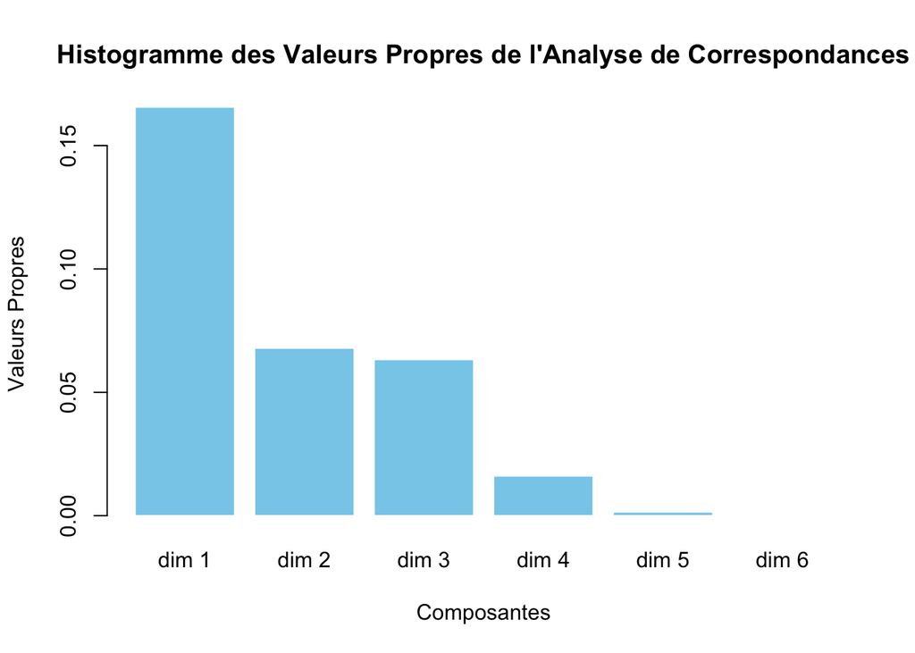

Ces résultats nous fournissent des informations sur les valeurs propres ainsi que la variance expliquée, qui correspond à l’explication de la variabilité des données observées.

Règle du coude : on retient 3 valeurs propres qui représentent 94,31 % de l’inertie. Cela signifie que ces trois valeurs expliquent à elles seules la majeure partie de l’information.

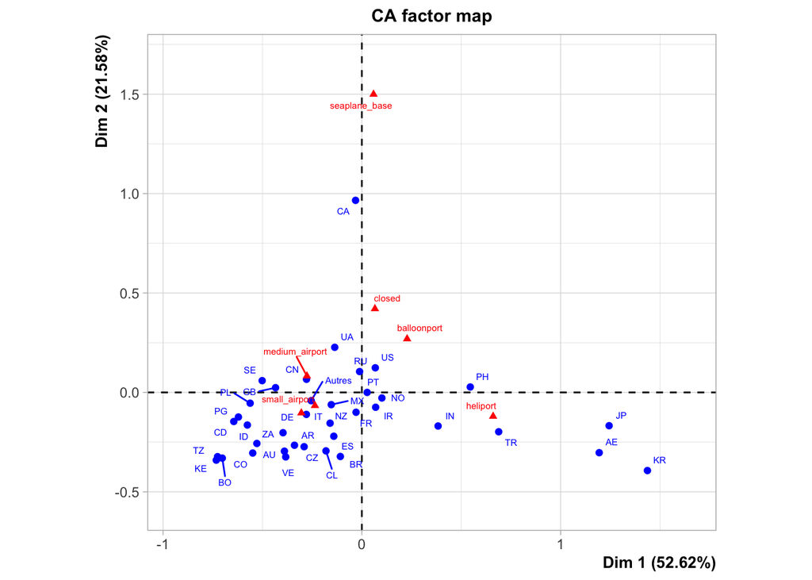

À ce niveau, nous nous focaliserons sur les deux premiers axes pour analyser les données. Ces deux dimensions expliquent 74,19 % de l’information (variance expliquée).

Les types d’aéroports qui sont bien représentés sur le premier axe sont les héliports (heliport) et les petits aéroports (small_airport). De plus, l’héliport contribue en grande partie à la construction du premier axe, sans oublier la contribution des petits aéroports. Ce premier axe oppose les héliports aux petits aéroports. Sur cet axe, des pays comme le Japon et la Corée du Sud sont bien représentés et contribuent fortement à la construction du premier axe.

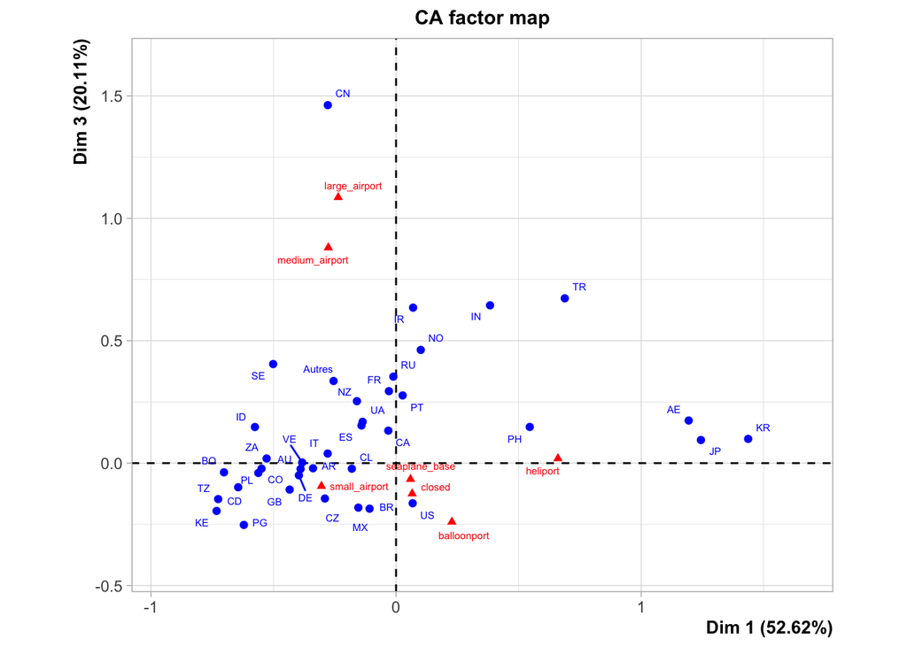

Nous nous attarderons sur les dimensions 1 et 3 pour effectuer notre analyse. Cela nous permet de comprendre l’évolution de nos données avec une vision panoramique et différente de la précédente. En effet, d’autres variables qui n’ont pas eu d’effet sur les autres dimensions peuvent s’avérer importantes.

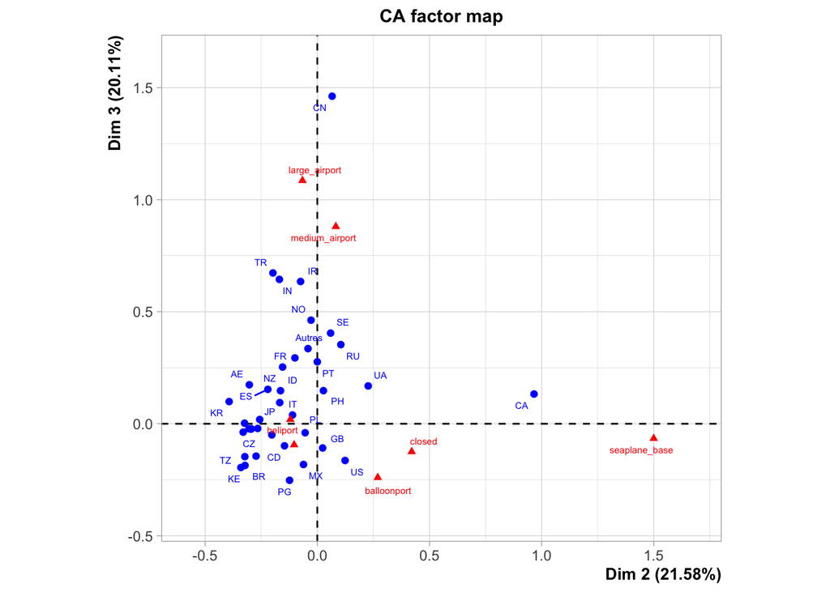

Cela nous permet de comparer les politiques de ces deux pays en termes d’infrastructures aéroportuaires. La politique aéroportuaire du Canada et de la Chine répond à des besoins et à des contextes très différents. Le Canada privilégie une approche flexible et régionale, adaptée à son vaste territoire et aux particularités géographiques, en utilisant des solutions comme les hydravions pour desservir les zones isolées. La Chine, quant à elle, adopte une approche ambitieuse et centralisée pour développer ses infrastructures, en réponse à une forte demande intérieure et internationale, en se concentrant sur la construction rapide de moyens aéroports et la modernisation des infrastructures existantes pour soutenir sa croissance économique.

## L’ACP

La deuxième partie concerne l’analyse en Composantes Principales (ACP), qui est une méthode statistique utilisée pour analyser et réduire la dimensionnalité d’un jeu de données tout en préservant autant que possible l’information. Elle est souvent utilisée dans des contextes où les données sont de haute dimension, c’est-à-dire lorsqu’il y a de nombreuses variables (caractéristiques) qui peuvent être difficiles à analyser ou à visualiser.

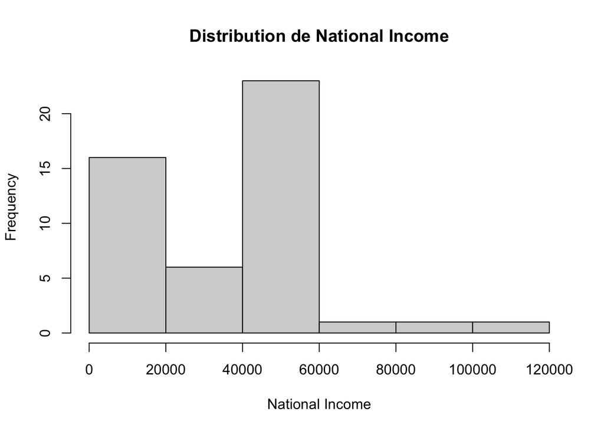

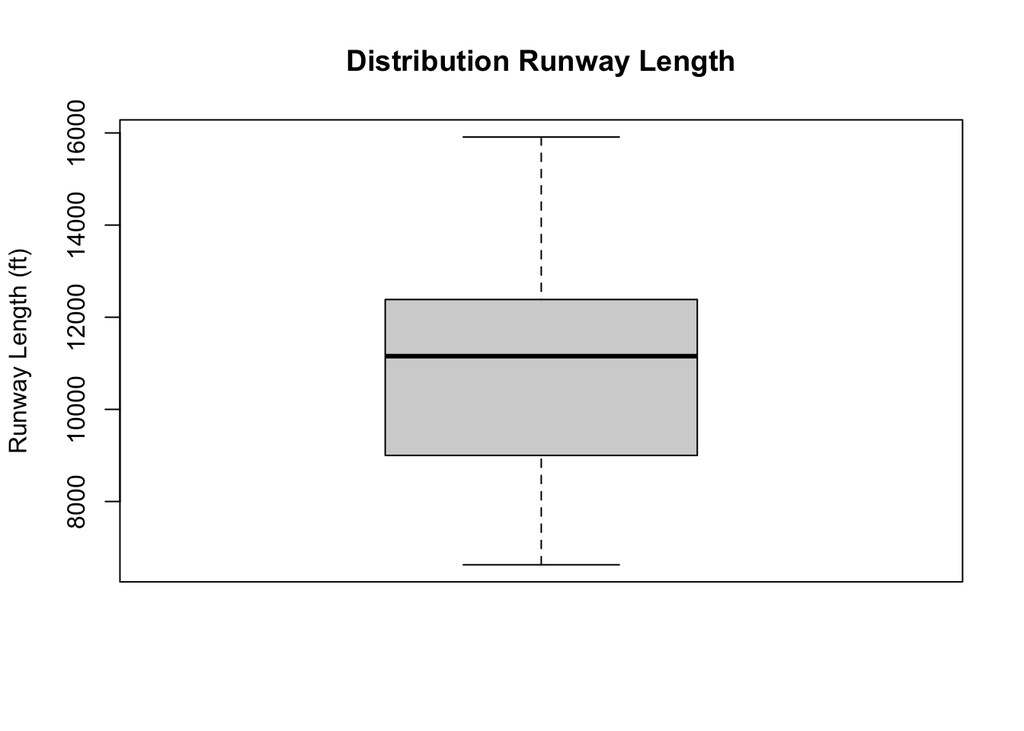

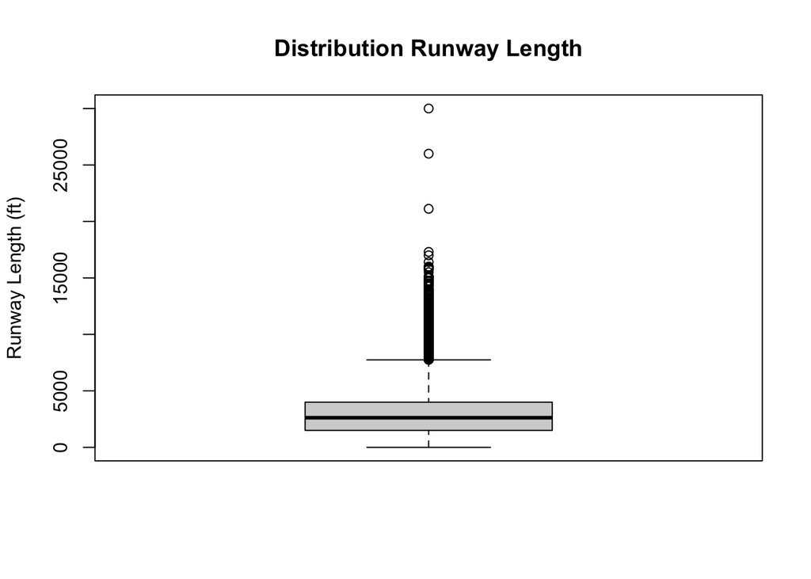

La comparaison des longueurs de pistes met en évidence une nette disparité entre les grands aéroports et les petites pistes d’aviation. Les 50 principaux aéroports disposent de pistes nettement plus longues et plus homogènes, avec une médiane autour de 11 000 pieds, reflétant leur capacité à accueillir de grands avions comme les avions gros-porteurs. En revanche, l’ensemble des 75 052 aéroports montre que la plupart des pistes sont beaucoup plus courtes, avec une médiane inférieure à 5 000 pieds, représentant des petits aérodromes régionaux, privés ou ruraux. Cependant, ce dataset inclut également des valeurs extrêmes, avec des pistes dépassant les 30 000 pieds, correspondant aux grands aéroports internationaux. Dans l’ensemble, la distribution est fortement asymétrique, soulignant la différence entre les petites pistes et quelques grands hubs internationaux.

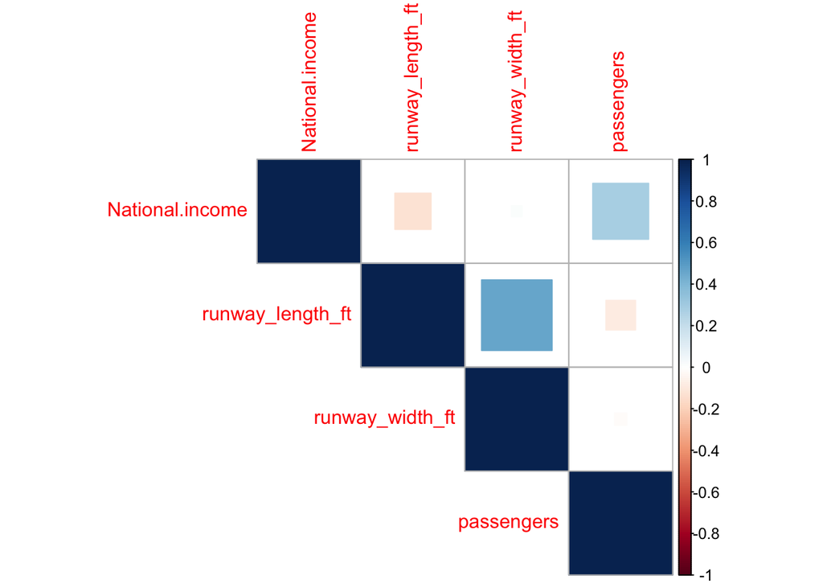

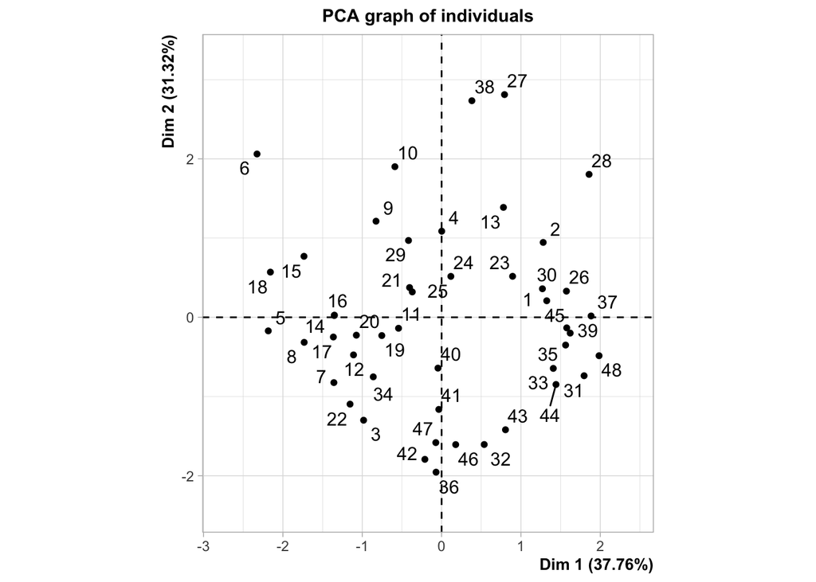

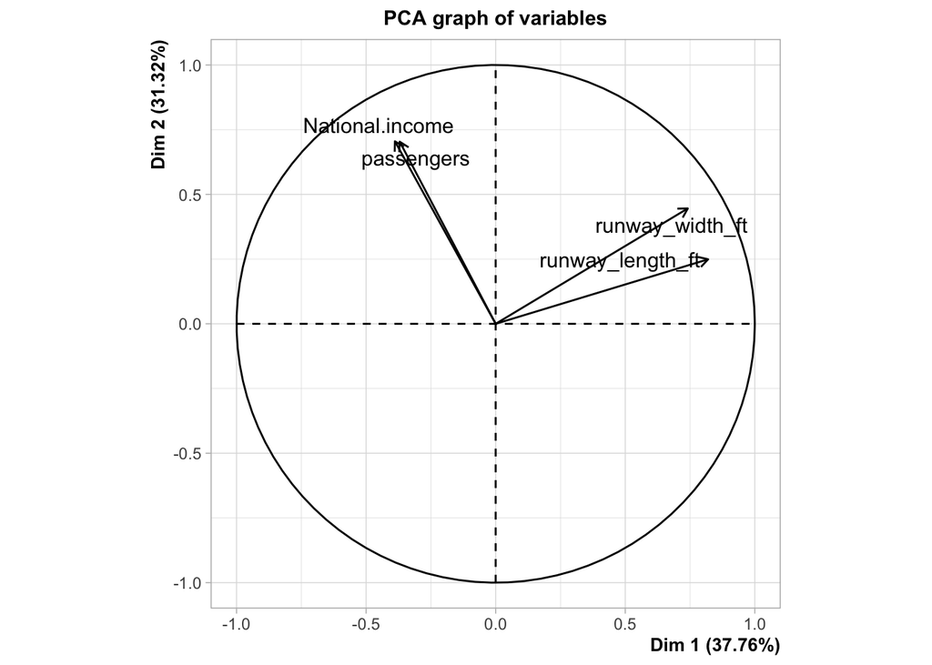

```
##        eigenvalue percentage of variance cumulative percentage of variance
## comp 1  1.5104137               37.76034                          37.76034
## comp 2  1.2527188               31.31797                          69.07831
## comp 3  0.7158910               17.89728                          86.97559
## comp 4  0.5209765               13.02441                         100.00000
```

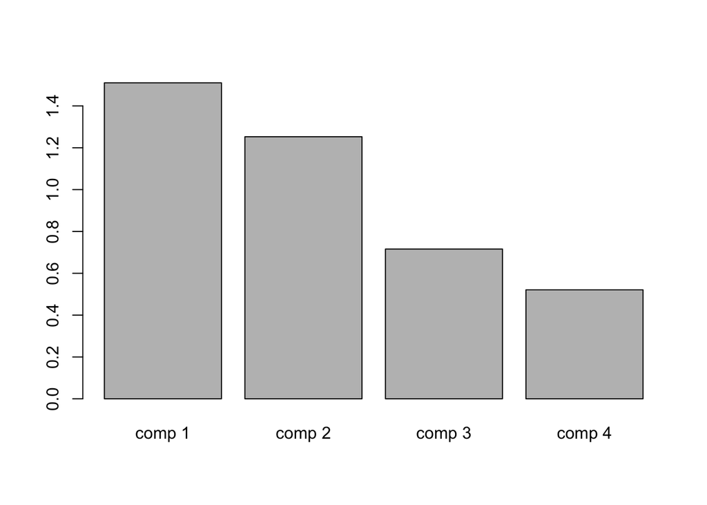

# **Source**

Airports : https://www.kaggle.com/datasets/danishjmeo/world-airports-data

Top airports : https://en.wikipedia.org/wiki/List_of_busiest_airports_by_passenger_traffic

ISO codes : https://en.wikipedia.org/wiki/List_of_ISO_3166_country_codes

National Income : https://wid.world/data/